# Assignment 2

- Please submit your answers on CANVAS.
- Two files are required on submission:
  - A pdf that includes all the conceptual part. You may take photos of your hand-writing hardcopy and compile into a pdf.
  - An html or pdf file generated by ipynb/rmd that includes all the codes and results from the coding part.
  - The raw ipynb/rmd is optional. If you cannot compile the rmd/ipynb, you may screenshot the codes and results in the coding part and then include them in a single pdf.

## Problems from the textbook

Text book ISLR 2nd Edition

- Chapter 4: 1, 2, 3, 13, 14.
- Chapter 5: 1, 2, 5, 6.

Make sure you use 2nd edition of the textbook.

## Task

Use the following code to construct a data with 100 samples of 1000 independent variables (X) and a response variable (y). Then implement the 10-fold cross-validation to estimate prediction Mean Squared Error (MSE) with the following two screen procedures:

1. screen-then-validate procedure: First conduct marginal regression to select $m$ most relevant variables (in terms of p-value) using all samples, and then use cross-validation to estimate prediction MSE based on the selected variables.
2. screen-while-validate procedure. Conduct the marginal regression to select $m$ variables but using only the training samples within each fold of the 10-fold cross-validation.

You should vary $m\in\{2,5,10,15,20\}$ and visualize the results. Compare the estimates of MSE using the approaches above. What is your observation? Which one should be use?

Note: Your results should be silimar to Fig1.

```r
set.seed(1)
n <- 100
p <- 1000
nfolds <- 10 # number of folds
nvar <- c(2,5,10,15,20) # number of variables to select

# generate dataset
X <- scale(matrix(rnorm(n*p),n,p))
y <- rnorm(n,0,1) # y is independent of X

data_full <- data.frame(y,X)


#################### functions you may use ####################
# compute pvalues of marginal regression
pval_marg <- function(y,X){
  fit_marg <- lm(y~.,data.frame(y,X))
  pval <- summary(fit_marg)$coefficients[2,4]
  return(pval)
}

# compute pvalues of marginal regression for a data frame
reg_marg <- function(data) apply(data[,-1],2,pval_marg,y=data[,1])
```

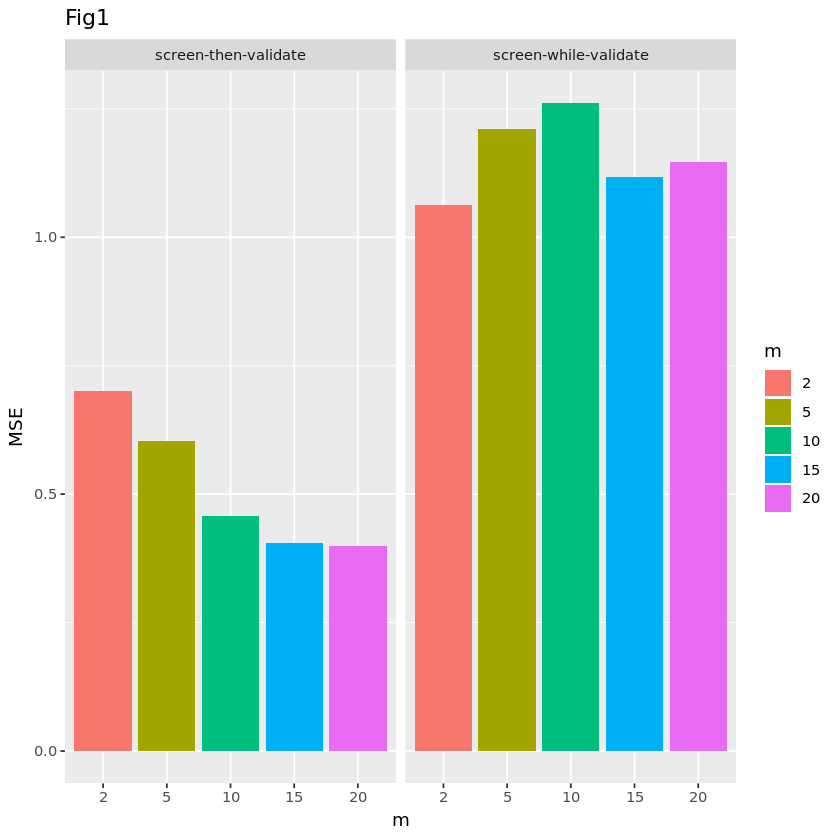

```r
library(ggplot2)
dat_mse <- data.frame(MSE=c(rowMeans(mse1),rowMeans(mse2)),m=factor(nvar),Method=rep(c("screen-then-validate","screen-while-validate"),each=length(nvar)))


ggplot(dat_mse,aes(x=m,y=MSE,fill=m)) + geom_bar(stat="identity",position = position_dodge2()) + facet_grid(.~Method) + ggtitle("Fig1")
```